# Sentinella data summary v1

2023-04-28

## Summary of components 1

The sentinella data is made up of 2 basic components.

- Consulations. These are clinical consultations reported by general doctors for both ARI (Acute respiratory infections) and ILI (Influenza Like Infections) - According to FOPH ILI is a subset of ARI - so I use ARI as ‘total consultations’
- Test results. A selection of consultations are then swabbed and the samples are sent for laboritory testing. They test for a panel of pathogens - we get data on positive/negative test results for Influenza A, Influenza B, RSV and SARS-CoV-2.

## Sentinella regions

All the data we recieve is reported weekly for 6 ‘sentinella regions’:

```
##                        region region_nr
## 1:             GE, NE, VD, VS         1
## 2:                 BE, FR, JU         2
## 3:             AG, BL, BS, SO         3
## 4:     LU, OW, NW, UR, SZ, ZG         4
## 5: AI, AR, GL, SG, SH, TG, ZH         5
## 6:                     GR, TI         6
```

## Summary of components 2

we have data since autumn 2020. The number of consultations reported in a given week ranges between 3 and 392. Here are the consultations for the past 3 seasons by region.

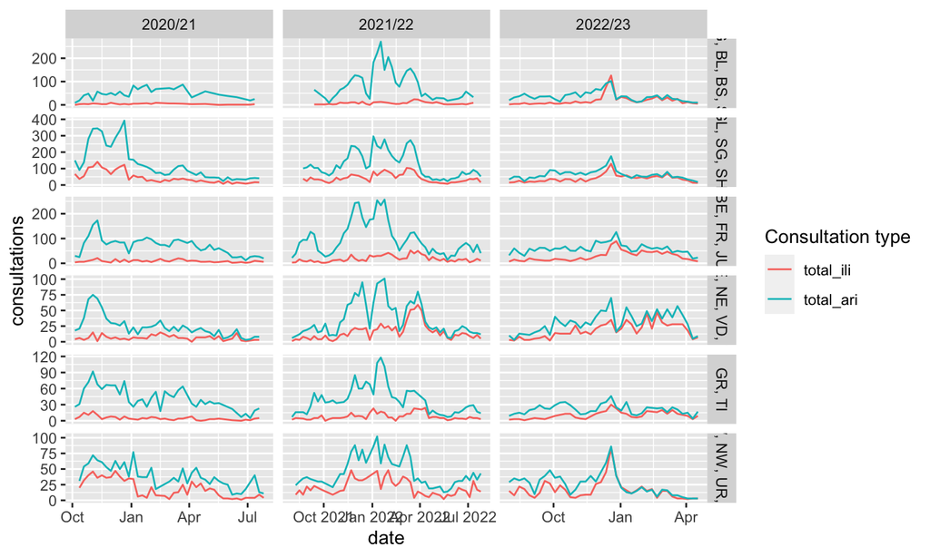

## Summary of components 3

Test results are also reported by region weekly and represent a subset of the consultaions.

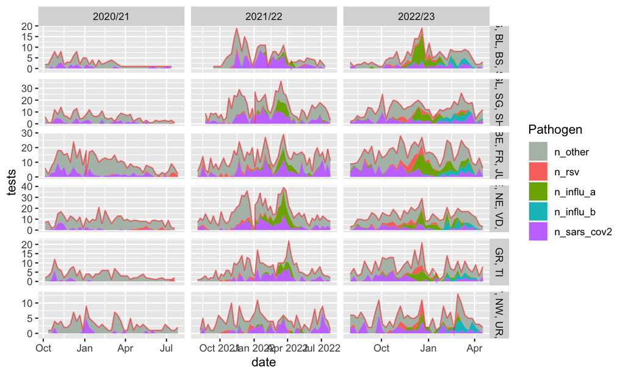

```r
sentinella_summary_tests[, n_other := n_samples - n_rsv - n_influ_a - n_influ_b - n_sars_cov2]
sentinella_summary_tests[, c('date', 'n_samples', 'n_rsv', 'n_influ_a', 'n_influ_b', 'n_sars_cov2', 'n_other', 'region', 'measuring_period')] |>
                           melt(
                             measure.vars = c('n_other', 'n_rsv', 'n_influ_a', 'n_influ_b', 'n_sars_cov2'),
                             value.name = 'tests',
                             variable.name = 'test_type') |>
ggplot()+
  geom_area(aes(x=date, y=tests, fill=test_type)) +
  geom_line(aes(x=date, y=n_samples), color='red', size=0.5, alpha=0.5)  +
  facet_grid(region~measuring_period, scales='free') +
  scale_fill_manual(name='Pathogen', values = c('#B2BEB5', scales::hue_pal()(4)))
```

Note that SARS-CoV-2 really dominates the positive tests for much of the monitored period.

## Summary of components 4

- Strong correlation between samples and consultations in some regions
- Some substantial outliers with very few tests for large numbers of consultations.
- In general proportion of consultations sent for testing reduced with the number of consultations.

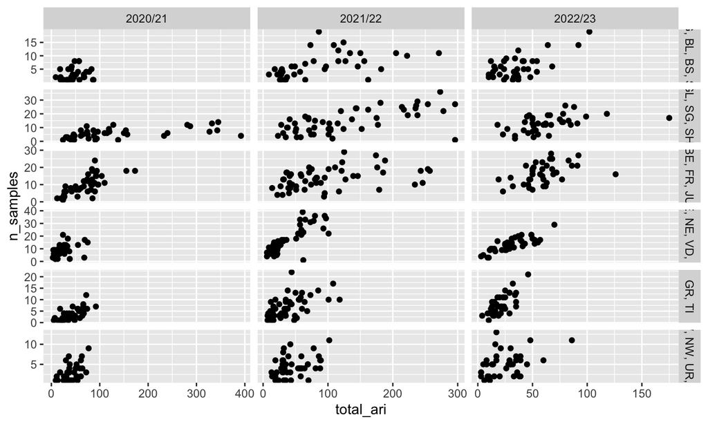

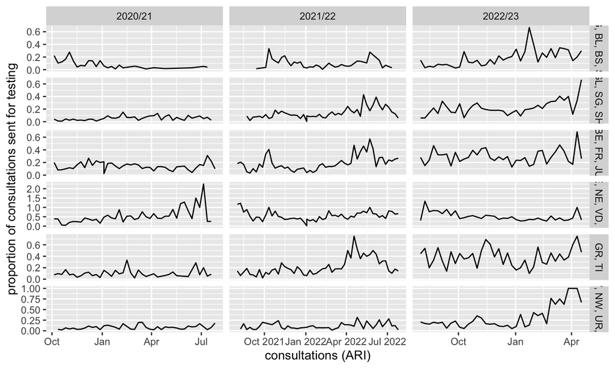

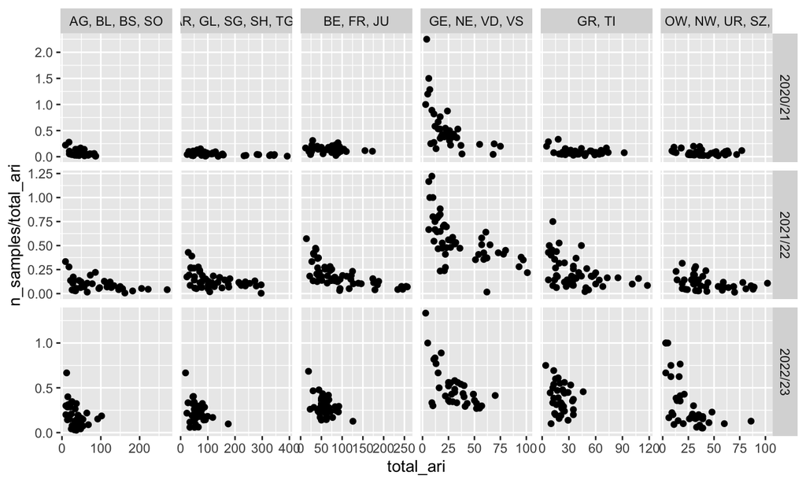